# JOINing Two Tables

36-350 – Statistical Computing

Week 14 – Spring 2019

# Foreign Keys

A foreign key is a(n) (collection of) column(s) in one table that *uniquely* specifies a row in another table. We specify foreign keys using the `REFERENCES` keyword when we define a column or table. Though it is not required to do so, it is most common for a foreign key to reference another table’s primary key.

Assume you have the following table:

```
create table countries ( country_code char(2) PRIMARY KEY, country_name text UNIQUE );
```

populated with

```
insert into countries values ('us','United States'), ('mx','Mexico');
```

We can then define another table, `cities`, that contains a foreign key referencing `country_code`:

```
create table cities (
  name text NOT NULL,
  postal_code varchar(9) CHECK (postal_code <> '') PRIMARY KEY,
  country_code char(2) CHECK (country_code <> ''),
  FOREIGN KEY (country_code) REFERENCES countries
);
insert into cities values ('Pittsburgh','15213','us');
insert into cities values ('Toronto','M4C185','ca');
```

The first insert will work, because the table countries contains the code `us`, while the second insert will fail (at least until information on Canada is inserted into `countries`).

# JOIN

The purpose of a `JOIN` is to allow a single `SELECT` command to access information in two tables. There are many flavors of joins: inner joins, left joins, full outer joins, set differences, etc.

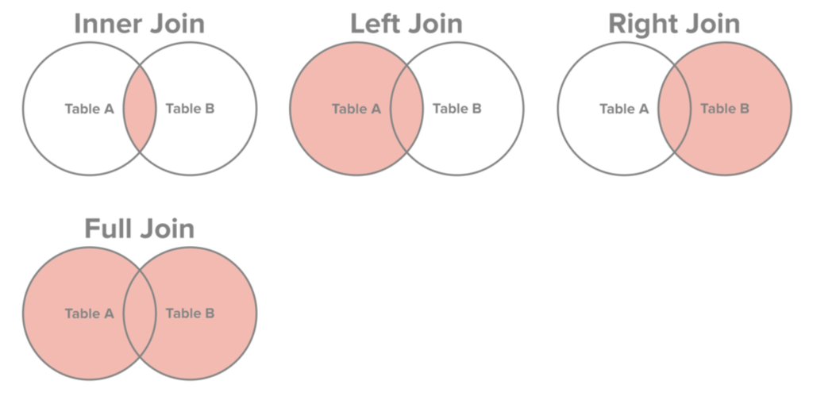

This just shows some of the possibilities. A query for set differences, for instance, might return all rows of Table A that are *not* in Table B.

# JOIN

We’ll begin by demonstrating an *inner* join, which produces rows for which the columns in **both** tables match. (This is akin to performing a `SELECT` on the *intersection* of two tables.)

```
create table A (id SERIAL PRIMARY KEY, name text);
insert into A (name) values ('Freeman'),('Greenhouse');
create table B (id SERIAL PRIMARY KEY, name text);
insert into B (name) values ('Tibshirani'),('Nugent'),('Freeman');
select * from A JOIN B on A.name = B.name;
```

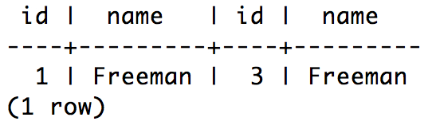

Instead of displaying all columns, you can as a subset, and rename them with “AS”:

```
select A.name as name_a,b.name as name_b from A JOIN B on A.name = B.name;
```

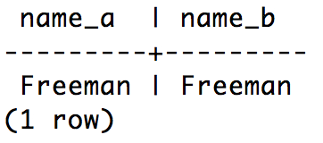

# JOIN

A *full outer join* produces rows for all columns in **both** tables. This is akin to performing a `SELECT` on the *union* of the two tables.

```
select A.name as name_a,B.name as name_b from A FULL OUTER JOIN B on A.name = B.name;
```

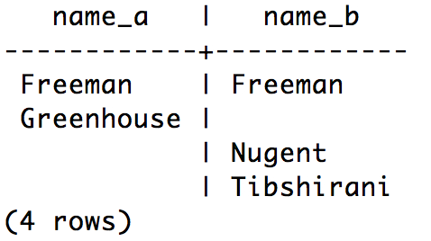

A *left outer join* produces all rows for the first table (here: A), and any matching rows for the second table (here: B).

```
select * from A LEFT OUTER JOIN B on A.name = B.name;
```

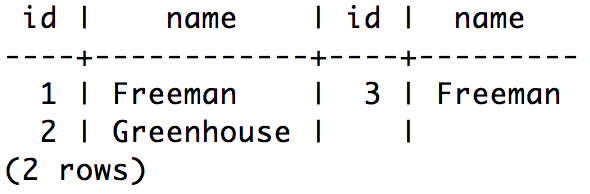

(Yes, there indeed is a `RIGHT OUTER JOIN` too.)

# JOIN

To select the set difference, e.g., all rows of A that are **not** in B, use a left or right outer join along with judicious `WHERE` clause:

```
select * from A LEFT OUTER JOIN B on A.name = B.name WHERE B.id IS NULL;
```

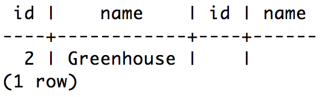

To select the symmetric difference, i.e., all rows of A not in B and vice-versa, use a full outer join along with a longer but still judicious `WHERE` clause:

```
select * from A FULL OUTER JOIN B on A.name = B.name WHERE B.id IS NULL OR A.id IS NULL;
```

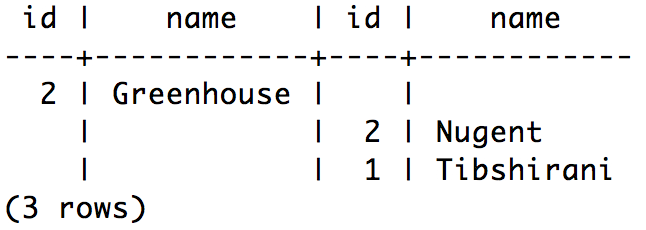